# R Notebook

# Part 1

### Load in libraries and data

```r
library(relaimpo)
library(modelr)
library(GGally)
library(lm.beta)
library(janitor)
library(lubridate)
library(fastDummies)
library(tidyverse)
avocado <- read_csv("data/avocado.csv") %>%
  clean_names()
```

Initial look at data:

```r
glimpse(avocado)
```

```
Rows: 18,249
Columns: 14
$ x1            <dbl> 0, 1, 2, 3, 4, 5, 6, 7, 8, 9, 10, 11, 1…
$ date          <date> 2015-12-27, 2015-12-20, 2015-12-13, 20…
$ average_price <dbl> 1.33, 1.35, 0.93, 1.08, 1.28, 1.26, 0.9…
$ total_volume  <dbl> 64236.62, 54876.98, 118220.22, 78992.15…
$ x4046         <dbl> 1036.74, 674.28, 794.70, 1132.00, 941.4…
$ x4225         <dbl> 54454.85, 44638.81, 109149.67, 71976.41…
$ x4770         <dbl> 48.16, 58.33, 130.50, 72.58, 75.78, 43.…
$ total_bags    <dbl> 8696.87, 9505.56, 8145.35, 5811.16, 618…
$ small_bags    <dbl> 8603.62, 9408.07, 8042.21, 5677.40, 598…
$ large_bags    <dbl> 93.25, 97.49, 103.14, 133.76, 197.69, 1…
$ x_large_bags  <dbl> 0, 0, 0, 0, 0, 0, 0, 0, 0, 0, 0, 0, 0, …
$ type          <chr> "conventional", "conventional", "conven…
$ year          <dbl> 2015, 2015, 2015, 2015, 2015, 2015, 201…
$ region        <chr> "Albany", "Albany", "Albany", "Albany",…
```

```r
summary(avocado)
```

```
       x1             date            average_price
 Min.   : 0.00   Min.   :2015-01-04   Min.   :0.440
 1st Qu.:10.00   1st Qu.:2015-10-25   1st Qu.:1.100
 Median :24.00   Median :2016-08-14   Median :1.370
 Mean   :24.23   Mean   :2016-08-13   Mean   :1.406
 3rd Qu.:38.00   3rd Qu.:2017-06-04   3rd Qu.:1.660
 Max.   :52.00   Max.   :2018-03-25   Max.   :3.250
  total_volume          x4046              x4225
 Min.   :      85   Min.   :       0   Min.   :       0
 1st Qu.:   10839   1st Qu.:     854   1st Qu.:    3009
 Median :  107377   Median :    8645   Median :   29061
 Mean   :  850644   Mean   :  293008   Mean   :  295155
 3rd Qu.:  432962   3rd Qu.:  111020   3rd Qu.:  150207
 Max.   :62505647   Max.   :22743616   Max.   :20470573
     x4770           total_bags         small_bags
 Min.   :      0   Min.   :       0   Min.   :       0
 1st Qu.:      0   1st Qu.:    5089   1st Qu.:    2849
 Median :    185   Median :   39744   Median :   26363
 Mean   :  22840   Mean   :  239639   Mean   :  182195
 3rd Qu.:   6243   3rd Qu.:  110783   3rd Qu.:   83338
 Max.   :2546439   Max.   :19373134   Max.   :13384587
   large_bags       x_large_bags          type
 Min.   :      0   Min.   :     0.0   Length:18249
 1st Qu.:    127   1st Qu.:     0.0   Class :character
 Median :   2648   Median :     0.0   Mode  :character
 Mean   :  54338   Mean   :  3106.4
 3rd Qu.:  22029   3rd Qu.:   132.5
 Max.   :5719097   Max.   :551693.7
      year         region
 Min.   :2015   Length:18249
 1st Qu.:2015   Class :character
 Median :2016   Mode  :character
 Mean   :2016
 3rd Qu.:2017
 Max.   :2018
```

```r
view(avocado)
```

I have chosen to build an explanatory model for the average_price.

#Tidying avocado group the region data to make it easier to use

i looked into the region and decide to group by “east”, “mid_west” & “west” to try shorten the lenth of thid data set and make it easier to interperate

```r
avocado_clean <- avocado %>%
  select(-c(x1, date, year)) %>%
  mutate(region = as.character(region)) %>%
  mutate(region = if_else(str_detect(region,
 "Albany|BaltimoreWashington|BuffaloRochester|Boston|Charlotte|Detroit|HarrisburgScranton|HartfordSpringfield|Indianapolis|Jacksonville|Nashville|NewYork|Northeast|NorthernNewEngland|Orlando|Philadelphia|Pittsburgh|RichmondNorfolk|Roanoke|SouthCarolina|Southeast|Syracuse|Tampa|MiamiFtLauderdale|Atlanta"), "east", region)) %>%
  mutate(region = if_else(str_detect(region,
 "Chicago|CincinnatiDayton|DallasFtWorth|Denver|Houston|Columbus|GreatLakes|Louisville|GrandRapids|Midsouth|NewOrleansMobile|Plains|StLouis"), "mid_west", region)) %>%
   mutate(region = if_else(str_detect(region,
 "Boise|California|DallasFtWorth|Denver|Houston|LasVegas|LosAngeles|PhoenixTucson|Portland|RaleighGreensboro|Sacramento|SanDiego|SanFrancisco|Seattle|SouthCentral|Spokane|WestTexNewMexico"), "west", region)) %>%
  mutate(region = as.factor(region))
glimpse(avocado_clean)
```

```
Rows: 18,249
Columns: 11
$ average_price <dbl> 1.33, 1.35, 0.93, 1.08, 1.28, 1.26, 0.99, 0.98, 1.02, 1.07, 1.12, 1…
$ total_volume  <dbl> 64236.62, 54876.98, 118220.22, 78992.15, 51039.60, 55979.78, 83453.…
$ x4046         <dbl> 1036.74, 674.28, 794.70, 1132.00, 941.48, 1184.27, 1368.92, 703.75,…
$ x4225         <dbl> 54454.85, 44638.81, 109149.67, 71976.41, 43838.39, 48067.99, 73672.…
$ x4770         <dbl> 48.16, 58.33, 130.50, 72.58, 75.78, 43.61, 93.26, 80.00, 85.34, 113…
$ total_bags    <dbl> 8696.87, 9505.56, 8145.35, 5811.16, 6183.95, 6683.91, 8318.86, 6829…
$ small_bags    <dbl> 8603.62, 9408.07, 8042.21, 5677.40, 5986.26, 6556.47, 8196.81, 6266…
$ large_bags    <dbl> 93.25, 97.49, 103.14, 133.76, 197.69, 127.44, 122.05, 562.37, 283.8…
$ x_large_bags  <dbl> 0.00, 0.00, 0.00, 0.00, 0.00, 0.00, 0.00, 0.00, 0.00, 0.00, 0.00, 0…
$ type          <chr> "conventional", "conventional", "conventional", "conventional", "co…
$ region        <fct> east, east, east, east, east, east, east, east, east, east, east, e…
```

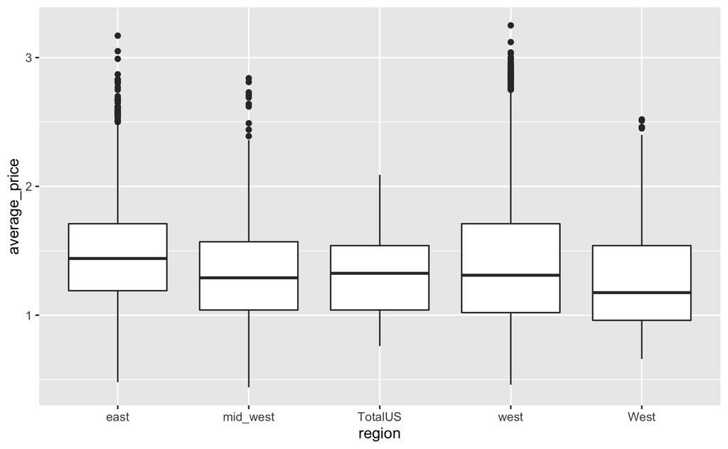

```r
avocado_clean %>%
  ggplot(aes(x = region, y = average_price)) +
  geom_boxplot()
```

The above data shows little difference un region so i have decided to drop the Rgion data and look into other variabkles

```r
avocado_clean <- avocado_clean %>%
  select(-region)
```

Check region has been dropped

```r
glimpse(avocado_clean)
```

[output not shown]

Now i will drop all NA values to make the further analysis easier.

```r
avocado_trimmed <- avocado_clean %>%
  drop_na()
dim(avocado_trimmed)
```

[output not shown]

Looking at the distribution for average_price:

```r
avocado_trimmed %>%
  ggplot(aes(average_price))+
  geom_histogram()
```

[output not shown]

Check for alias variables in data set

```r
alias(average_price ~ ., data = avocado_trimmed)
```

```
Model :
average_price ~ total_volume + x4046 + x4225 + x4770 + total_bags +
    small_bags + large_bags + x_large_bags + type
```

the above shows that we have no alias variable pressent within the data set.

Finding correlation between variables and average_price

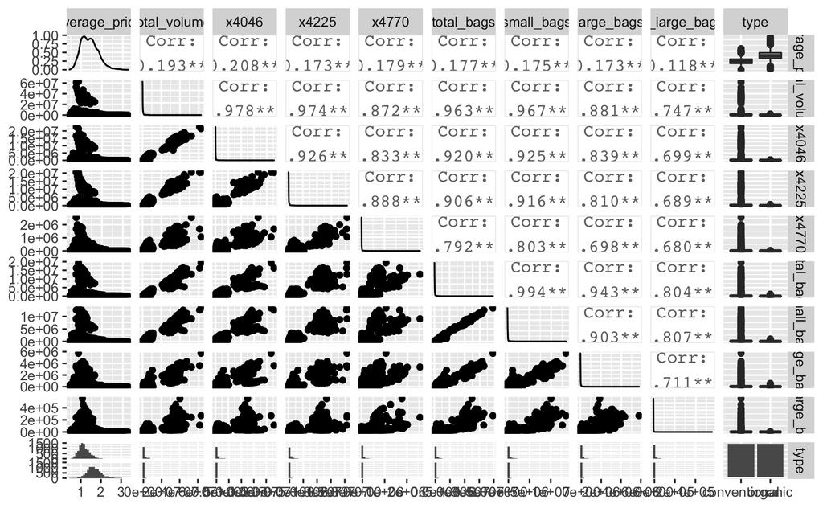

```r
ggpairs(avocado_trimmed)
```

Few of numeric variables show particularly strong correlation with average_price.

The highest correlation value is x4046 - 0.208 followed by total_volume - 0.193

The boxplot for type and average price shows separation between the two variable types.

# 1st predictor model building :

x4046 and average_price model

```r
mod1a <- mod1a <- lm(average_price ~ x4046, data = avocado_trimmed)
summary(mod1a)
```

[output not shown]

Residual standard error: 0.3939 on 18247 degrees of freedom Multiple R-squared: 0.0434

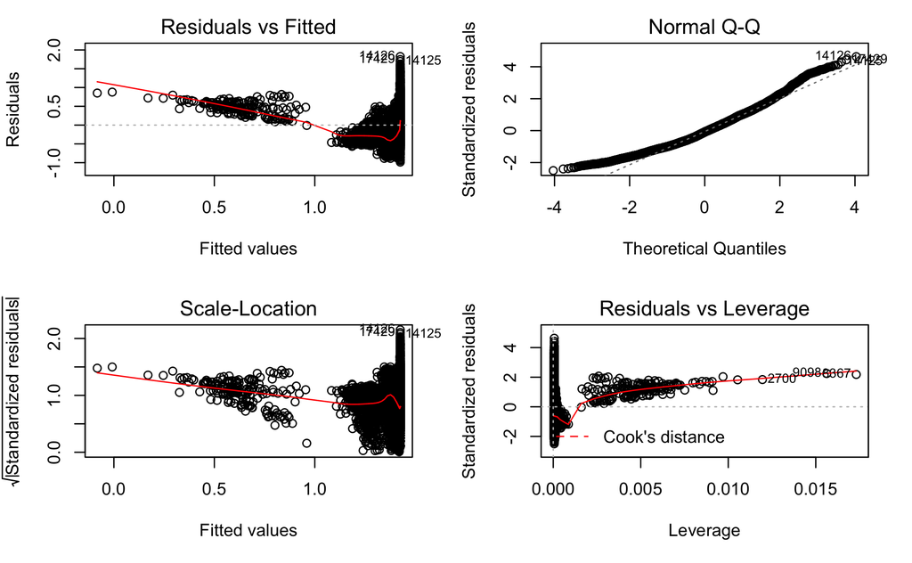

```r
par(mfrow = c(2,2))
plot(mod1a)
```

The residuals v fitted & scale-location plots show two different clusters in each diagram and a clear pattern.

total_volume & average_price model

```r
mod1b <- mod1b <- lm(average_price ~ total_volume, data = avocado_trimmed)
summary(mod1b)
```

```
Call:
lm(formula = average_price ~ total_volume, data = avocado_trimmed)

Residuals:
     Min       1Q   Median       3Q      Max
-0.98366 -0.29994 -0.03319  0.25498  1.82528

Coefficients:
               Estimate Std. Error t value Pr(>|t|)
(Intercept)   1.425e+00  3.012e-03  473.07   <2e-16 ***
total_volume -2.247e-08  8.470e-10  -26.54   <2e-16 ***
---
Signif. codes:  0 ‘***’ 0.001 ‘**’ 0.01 ‘*’ 0.05 ‘.’ 0.1 ‘ ’ 1

Residual standard error: 0.3951 on 18247 degrees of freedom
Multiple R-squared:  0.03715,   Adjusted R-squared:  0.0371
F-statistic: 704.1 on 1 and 18247 DF,  p-value: < 2.2e-16
```

Residual standard error: 0.3951 on 18247 degrees of freedom Multiple R-squared: 0.03715

Higher RSE and lower r-sq value than mod1a

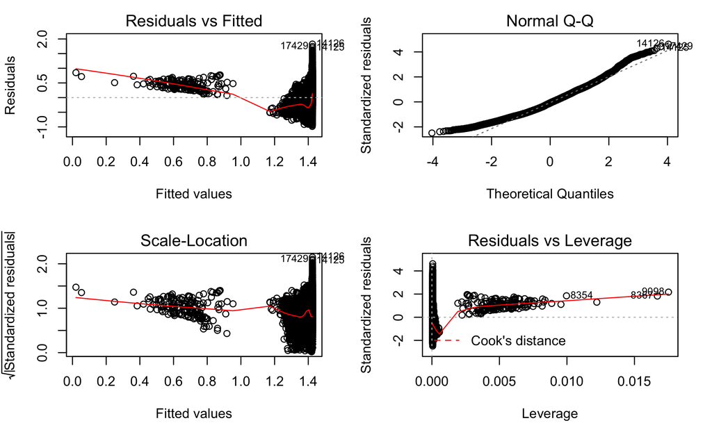

```r
par(mfrow = c(2,2))
plot(mod1b)
```

The residual v fitted & scale-location plots show clear patterns.

# 2nd Predictor

Adding residuals from mod1a and removing average_price and x4046

```r
avocado_res <- avocado_trimmed  %>%
  add_residuals(mod1a) %>%
  select(-c(average_price, x4046))
```

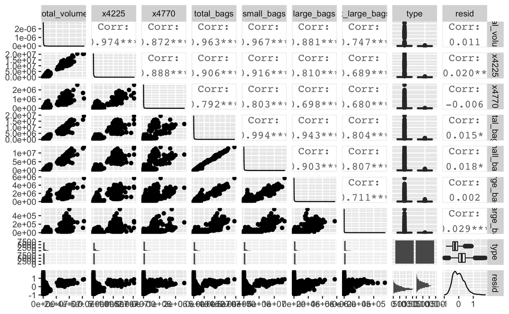

```r
ggpairs(avocado_res)
```

There appears to be no other variable that correlates particularly with the residuals apart from type.

```r
mod2 <- lm(average_price ~ x4046 + type, data = avocado_trimmed)
summary(mod2)
```

```
Call:
lm(formula = average_price ~ x4046 + type, data = avocado_trimmed)

Residuals:
     Min       1Q   Median       3Q      Max
-1.21416 -0.20029 -0.02736  0.18591  1.59589

Coefficients:
              Estimate Std. Error t value Pr(>|t|)
(Intercept)  1.171e+00  3.485e-03  336.13   <2e-16 ***
x4046       -2.323e-08  1.898e-09  -12.24   <2e-16 ***
typeorganic  4.827e-01  4.802e-03  100.52   <2e-16 ***
---
Signif. codes:  0 ‘***’ 0.001 ‘**’ 0.01 ‘*’ 0.05 ‘.’ 0.1 ‘ ’ 1

Residual standard error: 0.316 on 18246 degrees of freedom
Multiple R-squared:  0.3843,    Adjusted R-squared:  0.3843
F-statistic:  5695 on 2 and 18246 DF,  p-value: < 2.2e-16
```

Residual standard error: 0.316 on 18246 degrees of freedom Multiple R-squared: 0.3843

RSE is down from mod1a and r-sq value is greater too indicating a better model

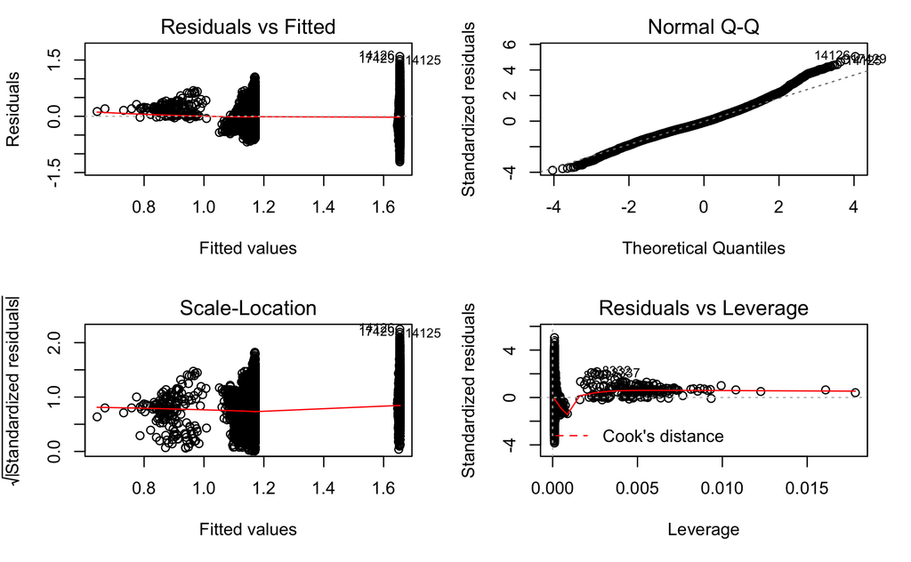

```r
par(mfrow = c(2,2))
plot(mod2)
```

Plots show points in vertical line due to categorical data type.

Adding interaction

```r
mod3 <- lm(average_price ~ x4046 + type + x4046:type, data = avocado_trimmed)
summary(mod3)
```

```
Call:
lm(formula = average_price ~ x4046 + type + x4046:type, data = avocado_trimmed)

Residuals:
     Min       1Q   Median       3Q      Max
-1.22604 -0.19907 -0.02641  0.18691  1.58753

Coefficients:
                    Estimate Std. Error t value Pr(>|t|)
(Intercept)        1.171e+00  3.472e-03  337.38   <2e-16 ***
x4046             -2.292e-08  1.891e-09  -12.12   <2e-16 ***
typeorganic        4.951e-01  4.895e-03  101.14   <2e-16 ***
x4046:typeorganic -1.676e-06  1.402e-07  -11.95   <2e-16 ***
---
Signif. codes:  0 ‘***’ 0.001 ‘**’ 0.01 ‘*’ 0.05 ‘.’ 0.1 ‘ ’ 1

Residual standard error: 0.3148 on 18245 degrees of freedom
Multiple R-squared:  0.3891,    Adjusted R-squared:  0.389
F-statistic:  3874 on 3 and 18245 DF,  p-value: < 2.2e-16
```

Residual standard error: 0.3148 on 18245 degrees of freedom Multiple R-squared: 0.3891

RSE is down from mod2 and r-sq value is greater too, indicating better model.

Testing relative importance

```r
calc.relimp(mod3, type = "lmg", rela = TRUE)
```

```
Response variable: average_price
Total response variance: 0.1621484
Analysis based on 18249 observations

3 Regressors:
x4046 typeorganic x4046:typeorganic
Proportion of variance explained by model: 38.91%
Metrics are normalized to sum to 100% (rela=TRUE).

Relative importance metrics:

                         lmg
x4046             0.06225772
typeorganic       0.92545265
x4046:typeorganic 0.01228963

Average coefficients for different model sizes:

                             1X           2Xs           3Xs
x4046             -6.631234e-08 -2.322774e-08 -2.292303e-08
typeorganic        4.959590e-01  4.826890e-01  4.951164e-01
x4046:typeorganic           NaN           NaN -1.675952e-06
```

Type looks to be by far the most important factor in regards to average_price. lmg value is 92.5%